# Descriptive Table Template

Jay Jeffries

8/2/2021

For the purposes of this code, **you will have to Knit output in html**. That is because the package {*kable*} depends entirely on html, and will not function if you attempt to output into pdf or Word format. Once you save output into html, you can copy + paste *any* table into the Word document of your choosing.

An awesome walkthrough of this package can be found here: https://haozhu233.github.io/kableExtra/awesome_table_in_html.html. Another R package that can make beautiful tables is the {*gt*} package explained here: https://gt.rstudio.com/

If in RStudio, when you click the **Knit** button a document will be generated that includes both content as well as the output of any embedded R code chunks within the document.

### Quick Dataset Exploration

```r
skim(mtcars) # data characteristics in dataframe format
```

Data summary

| Name | mtcars |
| --- | --- |
| Number of rows | 32 |
| Number of columns | 11 |
| _______________________ |  |
| Column type frequency: |  |
| numeric | 11 |
| ________________________ |  |
| Group variables | None |

**Variable type: numeric**

| skim_variable | n_missing | complete_rate | mean | sd | p0 | p25 | p50 | p75 | p100 | hist |
| --- | --- | --- | --- | --- | --- | --- | --- | --- | --- | --- |
| mpg | 0 | 1 | 20.09 | 6.03 | 10.40 | 15.43 | 19.20 | 22.80 | 33.90 | ▃▇▅▁▂ |
| cyl | 0 | 1 | 6.19 | 1.79 | 4.00 | 4.00 | 6.00 | 8.00 | 8.00 | ▆▁▃▁▇ |
| disp | 0 | 1 | 230.72 | 123.94 | 71.10 | 120.83 | 196.30 | 326.00 | 472.00 | ▇▃▃▃▂ |
| hp | 0 | 1 | 146.69 | 68.56 | 52.00 | 96.50 | 123.00 | 180.00 | 335.00 | ▇▇▆▃▁ |
| drat | 0 | 1 | 3.60 | 0.53 | 2.76 | 3.08 | 3.70 | 3.92 | 4.93 | ▇▃▇▅▁ |
| wt | 0 | 1 | 3.22 | 0.98 | 1.51 | 2.58 | 3.33 | 3.61 | 5.42 | ▃▃▇▁▂ |
| qsec | 0 | 1 | 17.85 | 1.79 | 14.50 | 16.89 | 17.71 | 18.90 | 22.90 | ▃▇▇▂▁ |
| vs | 0 | 1 | 0.44 | 0.50 | 0.00 | 0.00 | 0.00 | 1.00 | 1.00 | ▇▁▁▁▆ |
| am | 0 | 1 | 0.41 | 0.50 | 0.00 | 0.00 | 0.00 | 1.00 | 1.00 | ▇▁▁▁▆ |
| gear | 0 | 1 | 3.69 | 0.74 | 3.00 | 3.00 | 4.00 | 4.00 | 5.00 | ▇▁▆▁▂ |
| carb | 0 | 1 | 2.81 | 1.62 | 1.00 | 2.00 | 2.00 | 4.00 | 8.00 | ▇▂▅▁▁ |

```r
report(mtcars) # data characteristics in sentence format
```

```
## The data contains 32 observations of the following 11 variables:
##   - mpg: n = 32, Mean = 20.09, SD = 6.03, Median = 19.20, MAD = 5.41, range: [10.40, 33.90], Skewness = 0.67, Kurtosis = -0.02, 0 missing
##   - cyl: n = 32, Mean = 6.19, SD = 1.79, Median = 6.00, MAD = 2.97, range: [4, 8], Skewness = -0.19, Kurtosis = -1.76, 0 missing
##   - disp: n = 32, Mean = 230.72, SD = 123.94, Median = 196.30, MAD = 140.48, range: [71.10, 472], Skewness = 0.42, Kurtosis = -1.07, 0 missing
##   - hp: n = 32, Mean = 146.69, SD = 68.56, Median = 123.00, MAD = 77.10, range: [52, 335], Skewness = 0.80, Kurtosis = 0.28, 0 missing
##   - drat: n = 32, Mean = 3.60, SD = 0.53, Median = 3.70, MAD = 0.70, range: [2.76, 4.93], Skewness = 0.29, Kurtosis = -0.45, 0 missing
##   - wt: n = 32, Mean = 3.22, SD = 0.98, Median = 3.33, MAD = 0.77, range: [1.51, 5.42], Skewness = 0.47, Kurtosis = 0.42, 0 missing
##   - qsec: n = 32, Mean = 17.85, SD = 1.79, Median = 17.71, MAD = 1.42, range: [14.50, 22.90], Skewness = 0.41, Kurtosis = 0.86, 0 missing
##   - vs: n = 32, Mean = 0.44, SD = 0.50, Median = 0.00, MAD = 0.00, range: [0, 1], Skewness = 0.26, Kurtosis = -2.06, 0 missing
##   - am: n = 32, Mean = 0.41, SD = 0.50, Median = 0.00, MAD = 0.00, range: [0, 1], Skewness = 0.40, Kurtosis = -1.97, 0 missing
##   - gear: n = 32, Mean = 3.69, SD = 0.74, Median = 4.00, MAD = 1.48, range: [3, 5], Skewness = 0.58, Kurtosis = -0.90, 0 missing
##   - carb: n = 32, Mean = 2.81, SD = 1.62, Median = 2.00, MAD = 1.48, range: [1, 8], Skewness = 1.16, Kurtosis = 2.02, 0 missing
```

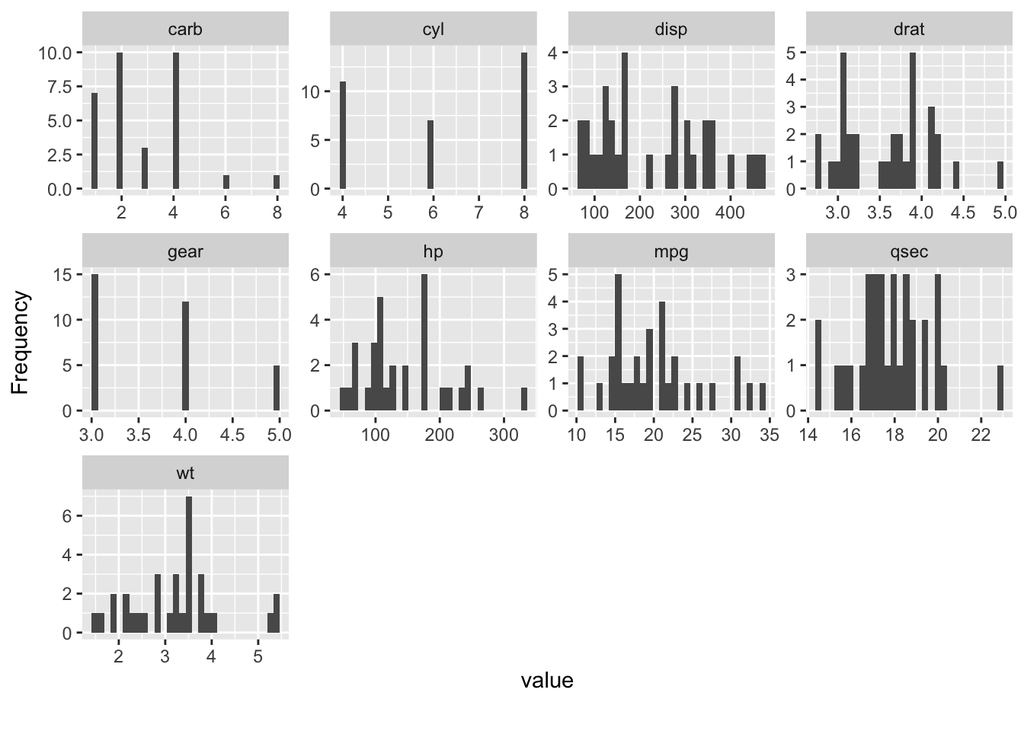

```r
plot_histogram(mtcars) # quickly creates facet-wrapped histograms for all continuous variables in the mtcars dataset
```

To practice descriptive tables, we will be using the built-in dataset called mtcars, or “motor trend cars”. As you can see, most of the variables are continuous in nature, while variables like “carb”, “cyl”, “or”gear" are discrete with finite levels. The main reason I know this is by checking out the mini-histogram printed on the far right of the skimr dataframe above. The report() output beneath this dataframe are for those that prefer reading written results over tabled results :)

### Terribly Basic Descriptive Table

```r
kbl(mtcars) %>%
  kable_styling()
```

|  | mpg | cyl | disp | hp | drat | wt | qsec | vs | am | gear | carb |
| --- | --- | --- | --- | --- | --- | --- | --- | --- | --- | --- | --- |
| Mazda RX4 | 21.0 | 6 | 160.0 | 110 | 3.90 | 2.620 | 16.46 | 0 | 1 | 4 | 4 |
| Mazda RX4 Wag | 21.0 | 6 | 160.0 | 110 | 3.90 | 2.875 | 17.02 | 0 | 1 | 4 | 4 |
| Datsun 710 | 22.8 | 4 | 108.0 | 93 | 3.85 | 2.320 | 18.61 | 1 | 1 | 4 | 1 |
| Hornet 4 Drive | 21.4 | 6 | 258.0 | 110 | 3.08 | 3.215 | 19.44 | 1 | 0 | 3 | 1 |
| Hornet Sportabout | 18.7 | 8 | 360.0 | 175 | 3.15 | 3.440 | 17.02 | 0 | 0 | 3 | 2 |
| Valiant | 18.1 | 6 | 225.0 | 105 | 2.76 | 3.460 | 20.22 | 1 | 0 | 3 | 1 |
| Duster 360 | 14.3 | 8 | 360.0 | 245 | 3.21 | 3.570 | 15.84 | 0 | 0 | 3 | 4 |
| Merc 240D | 24.4 | 4 | 146.7 | 62 | 3.69 | 3.190 | 20.00 | 1 | 0 | 4 | 2 |
| Merc 230 | 22.8 | 4 | 140.8 | 95 | 3.92 | 3.150 | 22.90 | 1 | 0 | 4 | 2 |
| Merc 280 | 19.2 | 6 | 167.6 | 123 | 3.92 | 3.440 | 18.30 | 1 | 0 | 4 | 4 |
| Merc 280C | 17.8 | 6 | 167.6 | 123 | 3.92 | 3.440 | 18.90 | 1 | 0 | 4 | 4 |
| Merc 450SE | 16.4 | 8 | 275.8 | 180 | 3.07 | 4.070 | 17.40 | 0 | 0 | 3 | 3 |
| Merc 450SL | 17.3 | 8 | 275.8 | 180 | 3.07 | 3.730 | 17.60 | 0 | 0 | 3 | 3 |
| Merc 450SLC | 15.2 | 8 | 275.8 | 180 | 3.07 | 3.780 | 18.00 | 0 | 0 | 3 | 3 |
| Cadillac Fleetwood | 10.4 | 8 | 472.0 | 205 | 2.93 | 5.250 | 17.98 | 0 | 0 | 3 | 4 |
| Lincoln Continental | 10.4 | 8 | 460.0 | 215 | 3.00 | 5.424 | 17.82 | 0 | 0 | 3 | 4 |
| Chrysler Imperial | 14.7 | 8 | 440.0 | 230 | 3.23 | 5.345 | 17.42 | 0 | 0 | 3 | 4 |
| Fiat 128 | 32.4 | 4 | 78.7 | 66 | 4.08 | 2.200 | 19.47 | 1 | 1 | 4 | 1 |
| Honda Civic | 30.4 | 4 | 75.7 | 52 | 4.93 | 1.615 | 18.52 | 1 | 1 | 4 | 2 |
| Toyota Corolla | 33.9 | 4 | 71.1 | 65 | 4.22 | 1.835 | 19.90 | 1 | 1 | 4 | 1 |
| Toyota Corona | 21.5 | 4 | 120.1 | 97 | 3.70 | 2.465 | 20.01 | 1 | 0 | 3 | 1 |
| Dodge Challenger | 15.5 | 8 | 318.0 | 150 | 2.76 | 3.520 | 16.87 | 0 | 0 | 3 | 2 |
| AMC Javelin | 15.2 | 8 | 304.0 | 150 | 3.15 | 3.435 | 17.30 | 0 | 0 | 3 | 2 |
| Camaro Z28 | 13.3 | 8 | 350.0 | 245 | 3.73 | 3.840 | 15.41 | 0 | 0 | 3 | 4 |
| Pontiac Firebird | 19.2 | 8 | 400.0 | 175 | 3.08 | 3.845 | 17.05 | 0 | 0 | 3 | 2 |
| Fiat X1-9 | 27.3 | 4 | 79.0 | 66 | 4.08 | 1.935 | 18.90 | 1 | 1 | 4 | 1 |
| Porsche 914-2 | 26.0 | 4 | 120.3 | 91 | 4.43 | 2.140 | 16.70 | 0 | 1 | 5 | 2 |
| Lotus Europa | 30.4 | 4 | 95.1 | 113 | 3.77 | 1.513 | 16.90 | 1 | 1 | 5 | 2 |
| Ford Pantera L | 15.8 | 8 | 351.0 | 264 | 4.22 | 3.170 | 14.50 | 0 | 1 | 5 | 4 |
| Ferrari Dino | 19.7 | 6 | 145.0 | 175 | 3.62 | 2.770 | 15.50 | 0 | 1 | 5 | 6 |
| Maserati Bora | 15.0 | 8 | 301.0 | 335 | 3.54 | 3.570 | 14.60 | 0 | 1 | 5 | 8 |
| Volvo 142E | 21.4 | 4 | 121.0 | 109 | 4.11 | 2.780 | 18.60 | 1 | 1 | 4 | 2 |

This table, while not *too* bad looking, it could use some adjustments and updating. It serves as a reference for the upcoming content. What if we want to add a title? Change the header? Group the rows or columns? Edit table fonts? Add color? Input scroll bars for larger tables?

**Lets do it!**

### Data Preparation and Examples

```r
mtcarsDesc = mtcars %>% # Creating a new dataset using the origina mtcars dataset
  group_by(carb) %>% # Grouping the dataset by the carb variable
  summarise(
    n = n(), # n, or sample size count
    Avg_mpg = round(mean(mpg, na.rm = TRUE),2), # the average mpg is rounded to 2 decimals (,2) and missing values are removed via na.rm = TRUE
    Avg_wt = round(mean(wt, na.rm = TRUE),2), # changing the (,2) will round the average to whatever number of decimal points you would prefer
    Avg_drat = round(mean(drat, na.rm = TRUE),2), # revising the name before the = (e.g. "Avg_drat") changes what appears in the table heading
    Avg_qsec = round(mean(qsec, na.rm = TRUE),2),
    Avg_hp = round(mean(hp, na.rm = TRUE),2),
    Avg_disp = round(mean(disp, na.rm = TRUE),2)
  )
```

The dataset mtcars does not inherently include means, counts, frequencies. Rather, it is raw data collected. That is likely your case. Depending on how you wish to use this template, you may need to prepare your data for analysis. Above, we grouped our dataset by the carburetor variable (6 levels), found the means for mpg, wt, drat, qsec, hp, and disp, and requested the count (n) for each carb group.

It is worth noting that na.rm removes the value if it is missing (it actually turns into and is treated as “NA” rather than 0). If you wish to perform listwise deletion of missing content–which I think would be a travesty–use:

deleteddata <- na.omit(your dataset)

To create a brand new dataset with all rows involving any missing values *removed*.

### Examples of Descriptive Tables

```r
# Table of Averages using the revised dataset we just made
kbl(mtcarsDesc, caption = "Figure 1. Motor Trend Cars Descriptive Statistics by Carborator") %>%
  # kbl() is a command from the kableExtra package (a revision to the Kable package) which will be used frequently here
  # I like to use caption = as a way to introduce the table's title!
  # remember, mtcarsDesc was just created above!
  add_header_above(c(" " = 2, "Mean Statistic" = 6)) %>%
  # Later on, we will get into how to make table subheadings
  kable_material("hover", font_size = 12, full_width = FALSE)
```

Figure 1. Motor Trend Cars Descriptive Statistics by Carborator

| carb | n | Mean Statistic Avg_mpg | Mean Statistic Avg_wt | Mean Statistic Avg_drat | Mean Statistic Avg_qsec | Mean Statistic Avg_hp | Mean Statistic Avg_disp |
| --- | --- | --- | --- | --- | --- | --- | --- |
| 1 | 7 | 25.34 | 2.49 | 3.68 | 19.51 | 86.0 | 134.27 |
| 2 | 10 | 22.40 | 2.86 | 3.70 | 18.19 | 117.2 | 208.16 |
| 3 | 3 | 16.30 | 3.86 | 3.07 | 17.67 | 180.0 | 275.80 |
| 4 | 10 | 15.79 | 3.90 | 3.60 | 16.96 | 187.0 | 308.82 |
| 6 | 1 | 19.70 | 2.77 | 3.62 | 15.50 | 175.0 | 145.00 |
| 8 | 1 | 15.00 | 3.57 | 3.54 | 14.60 | 335.0 | 301.00 |

```r
  # material and font customizations are described later on -- for now, try hovering your cursor over the tables
# Grouped Table of Counts
mtcars %>%
  group_by(cyl) %>%
  count(carb) %>%
  kbl(caption = "Figure 2. Count of Carborators by Cylinder Type") %>%
  kable_paper(font_size = 12) %>% # this is one of the 6 premade themes in the package, try out these options if you're feeling crazy:
  # kable_classic, kable_classic_2, kable_minimal, kable_material, kable_material_dark
  add_header_above(c("Car Part" = 2, "Count" = 1)) %>%
  kable_styling(full_width = FALSE) # kable_styling function allows you to specify additional formatting options; full_width = FALSE allows the table to be in its slimmer form instead of full-screen width
```

Figure 2. Count of Carborators by Cylinder Type

| Car Part cyl | Car Part carb | Count n |
| --- | --- | --- |
| 4 | 1 | 5 |
| 4 | 2 | 6 |
| 6 | 1 | 2 |
| 6 | 4 | 4 |
| 6 | 6 | 1 |
| 8 | 2 | 4 |
| 8 | 3 | 3 |
| 8 | 4 | 6 |
| 8 | 8 | 1 |

### Font and Position Edits to Descriptive Table

```r
kbl(mtcarsDesc) %>%
  kable_styling(font_size = 18, # font_size allows you to edit whatever size of font you'd like
                html_font = "serif", # serif = Times New Roman, sans = Arial, mono = Courier, and idk any others
                position = "left", # aligns the table to the left or right; centered is the default so entirely delete if unnecessary
                # "float_right" or "float_left" lets text wrap around the table depending on your preference
                full_width = FALSE) # full_width = FALSE reduces table to fit within margins instead of expand to full page
```

| carb | n | Avg_mpg | Avg_wt | Avg_drat | Avg_qsec | Avg_hp | Avg_disp |
| --- | --- | --- | --- | --- | --- | --- | --- |
| 1 | 7 | 25.34 | 2.49 | 3.68 | 19.51 | 86.0 | 134.27 |
| 2 | 10 | 22.40 | 2.86 | 3.70 | 18.19 | 117.2 | 208.16 |
| 3 | 3 | 16.30 | 3.86 | 3.07 | 17.67 | 180.0 | 275.80 |
| 4 | 10 | 15.79 | 3.90 | 3.60 | 16.96 | 187.0 | 308.82 |
| 6 | 1 | 19.70 | 2.77 | 3.62 | 15.50 | 175.0 | 145.00 |
| 8 | 1 | 15.00 | 3.57 | 3.54 | 14.60 | 335.0 | 301.00 |

```r
# By default, these tables take up 100% of the width of the output, which sometimes looks unsightly in RMarkdown and makes for a mess in Word
```

Theh code `full_width = FALSE` is necessary when copy + pasting html table output into Word effectively. Otherwise, the table margins do not fit into a typical Word document (but can be, with *force*..).

### General Customizations of Descriptive Table

```r
kbl(mtcarsDesc) %>%
  kable_material(c("striped", "hover", "condense", "responsive")) %>%
  kable_styling(fixed_thead = TRUE)
```

| carb | n | Avg_mpg | Avg_wt | Avg_drat | Avg_qsec | Avg_hp | Avg_disp |
| --- | --- | --- | --- | --- | --- | --- | --- |
| 1 | 7 | 25.34 | 2.49 | 3.68 | 19.51 | 86.0 | 134.27 |
| 2 | 10 | 22.40 | 2.86 | 3.70 | 18.19 | 117.2 | 208.16 |
| 3 | 3 | 16.30 | 3.86 | 3.07 | 17.67 | 180.0 | 275.80 |
| 4 | 10 | 15.79 | 3.90 | 3.60 | 16.96 | 187.0 | 308.82 |
| 6 | 1 | 19.70 | 2.77 | 3.62 | 15.50 | 175.0 | 145.00 |
| 8 | 1 | 15.00 | 3.57 | 3.54 | 14.60 | 335.0 | 301.00 |

```r
# "striped" makes every other row a light gray color
# "hover" helps to indicate which row your cursor is hovering over
# "condense" shortens the row height
# "responsive" makes the table responsive to horizontal scrolling (especially important when viewing on mobile devices)
# fixed_thead = TRUE freezes the column headings when you scroll up/down the table for very long tables
```

### Header Customizations of Descriptive Table

```r
kbl(mtcarsDesc) %>%
  kable_material(c("striped", "hover", "condense", "responsive")) %>%
  kable_styling(fixed_thead = list(enabled = TRUE, background = "teal")) %>% # to customize the header background try this with your own choice of color!
  # the code below introduces row_spec, meaning row specialization, which allows us to make more table customizations!
  row_spec(0, color = "lightgray") # this line edits the font of the header to be lightgray; notice here that the 0 means "row 0", aka the header
```

| carb | n | Avg_mpg | Avg_wt | Avg_drat | Avg_qsec | Avg_hp | Avg_disp |
| --- | --- | --- | --- | --- | --- | --- | --- |
| 1 | 7 | 25.34 | 2.49 | 3.68 | 19.51 | 86.0 | 134.27 |
| 2 | 10 | 22.40 | 2.86 | 3.70 | 18.19 | 117.2 | 208.16 |
| 3 | 3 | 16.30 | 3.86 | 3.07 | 17.67 | 180.0 | 275.80 |
| 4 | 10 | 15.79 | 3.90 | 3.60 | 16.96 | 187.0 | 308.82 |
| 6 | 1 | 19.70 | 2.77 | 3.62 | 15.50 | 175.0 | 145.00 |
| 8 | 1 | 15.00 | 3.57 | 3.54 | 14.60 | 335.0 | 301.00 |

### Customizing Rows/Columns Content in Descriptive Table

```r
kbl(mtcars) %>%
  kable_minimal(full_width = FALSE) %>%
  row_spec(2:3, bold = TRUE, italic = TRUE) %>% # content in row is bolded, italicized, and centered with these features
  column_spec(4:5, color = "darkgreen", background = "gold") %>% # color indicates font color while background indicates... yes.. the background color
  column_spec(6:7, underline = TRUE, strikeout = TRUE) %>% # underlining and strikeout of content within entire column
  row_spec(9:10, angle = 45) # angle will likely be unused (especially when row content runs into each other), but this is another option
```

|  | mpg | cyl | disp | hp | drat | wt | qsec | vs | am | gear | carb |
| --- | --- | --- | --- | --- | --- | --- | --- | --- | --- | --- | --- |
| Mazda RX4 | 21.0 | 6 | 160.0 | 110 | 3.90 | 2.620 | 16.46 | 0 | 1 | 4 | 4 |
| Mazda RX4 Wag | 21.0 | 6 | 160.0 | 110 | 3.90 | 2.875 | 17.02 | 0 | 1 | 4 | 4 |
| Datsun 710 | 22.8 | 4 | 108.0 | 93 | 3.85 | 2.320 | 18.61 | 1 | 1 | 4 | 1 |
| Hornet 4 Drive | 21.4 | 6 | 258.0 | 110 | 3.08 | 3.215 | 19.44 | 1 | 0 | 3 | 1 |
| Hornet Sportabout | 18.7 | 8 | 360.0 | 175 | 3.15 | 3.440 | 17.02 | 0 | 0 | 3 | 2 |
| Valiant | 18.1 | 6 | 225.0 | 105 | 2.76 | 3.460 | 20.22 | 1 | 0 | 3 | 1 |
| Duster 360 | 14.3 | 8 | 360.0 | 245 | 3.21 | 3.570 | 15.84 | 0 | 0 | 3 | 4 |
| Merc 240D | 24.4 | 4 | 146.7 | 62 | 3.69 | 3.190 | 20.00 | 1 | 0 | 4 | 2 |
| Merc 230 | 22.8 | 4 | 140.8 | 95 | 3.92 | 3.150 | 22.90 | 1 | 0 | 4 | 2 |
| Merc 280 | 19.2 | 6 | 167.6 | 123 | 3.92 | 3.440 | 18.30 | 1 | 0 | 4 | 4 |
| Merc 280C | 17.8 | 6 | 167.6 | 123 | 3.92 | 3.440 | 18.90 | 1 | 0 | 4 | 4 |
| Merc 450SE | 16.4 | 8 | 275.8 | 180 | 3.07 | 4.070 | 17.40 | 0 | 0 | 3 | 3 |
| Merc 450SL | 17.3 | 8 | 275.8 | 180 | 3.07 | 3.730 | 17.60 | 0 | 0 | 3 | 3 |
| Merc 450SLC | 15.2 | 8 | 275.8 | 180 | 3.07 | 3.780 | 18.00 | 0 | 0 | 3 | 3 |
| Cadillac Fleetwood | 10.4 | 8 | 472.0 | 205 | 2.93 | 5.250 | 17.98 | 0 | 0 | 3 | 4 |
| Lincoln Continental | 10.4 | 8 | 460.0 | 215 | 3.00 | 5.424 | 17.82 | 0 | 0 | 3 | 4 |
| Chrysler Imperial | 14.7 | 8 | 440.0 | 230 | 3.23 | 5.345 | 17.42 | 0 | 0 | 3 | 4 |
| Fiat 128 | 32.4 | 4 | 78.7 | 66 | 4.08 | 2.200 | 19.47 | 1 | 1 | 4 | 1 |
| Honda Civic | 30.4 | 4 | 75.7 | 52 | 4.93 | 1.615 | 18.52 | 1 | 1 | 4 | 2 |
| Toyota Corolla | 33.9 | 4 | 71.1 | 65 | 4.22 | 1.835 | 19.90 | 1 | 1 | 4 | 1 |
| Toyota Corona | 21.5 | 4 | 120.1 | 97 | 3.70 | 2.465 | 20.01 | 1 | 0 | 3 | 1 |
| Dodge Challenger | 15.5 | 8 | 318.0 | 150 | 2.76 | 3.520 | 16.87 | 0 | 0 | 3 | 2 |
| AMC Javelin | 15.2 | 8 | 304.0 | 150 | 3.15 | 3.435 | 17.30 | 0 | 0 | 3 | 2 |
| Camaro Z28 | 13.3 | 8 | 350.0 | 245 | 3.73 | 3.840 | 15.41 | 0 | 0 | 3 | 4 |
| Pontiac Firebird | 19.2 | 8 | 400.0 | 175 | 3.08 | 3.845 | 17.05 | 0 | 0 | 3 | 2 |
| Fiat X1-9 | 27.3 | 4 | 79.0 | 66 | 4.08 | 1.935 | 18.90 | 1 | 1 | 4 | 1 |
| Porsche 914-2 | 26.0 | 4 | 120.3 | 91 | 4.43 | 2.140 | 16.70 | 0 | 1 | 5 | 2 |
| Lotus Europa | 30.4 | 4 | 95.1 | 113 | 3.77 | 1.513 | 16.90 | 1 | 1 | 5 | 2 |
| Ford Pantera L | 15.8 | 8 | 351.0 | 264 | 4.22 | 3.170 | 14.50 | 0 | 1 | 5 | 4 |
| Ferrari Dino | 19.7 | 6 | 145.0 | 175 | 3.62 | 2.770 | 15.50 | 0 | 1 | 5 | 6 |
| Maserati Bora | 15.0 | 8 | 301.0 | 335 | 3.54 | 3.570 | 14.60 | 0 | 1 | 5 | 8 |
| Volvo 142E | 21.4 | 4 | 121.0 | 109 | 4.11 | 2.780 | 18.60 | 1 | 1 | 4 | 2 |

### Grouped Columns Descriptive Table

```r
kbl(mtcars, caption = "Figure 5. Grouped Columns Frequency Table") %>%
  # caption can act as a table title
  kable_minimal() %>% # One of my least-favorite premade table themes in regard to report-writing
  add_header_above(c("Car Name" = 1, "Group 1" = 5, "Group 2" = 4, "Group 3" = 2)) %>%
  # The abover code is "additive" in terms of columns, where the first listed item "Car Name" = 1 involves column 2,
  # "Group 1" = 5 includes the next 5 columns (columns 2:6) which is mpg through drat, "Group 2" = 5 are columns (7:12) wt through am, etc.
  kable_styling(full_width = FALSE)   # full_width = FALSE condenses the table into table with less spacing between columns
```

Figure 5. Grouped Columns Frequency Table

| Car Name | Group 1 mpg | Group 1 cyl | Group 1 disp | Group 1 hp | Group 1 drat | Group 2 wt | Group 2 qsec | Group 2 vs | Group 2 am | Group 3 gear | Group 3 carb |
| --- | --- | --- | --- | --- | --- | --- | --- | --- | --- | --- | --- |
| Mazda RX4 | 21.0 | 6 | 160.0 | 110 | 3.90 | 2.620 | 16.46 | 0 | 1 | 4 | 4 |
| Mazda RX4 Wag | 21.0 | 6 | 160.0 | 110 | 3.90 | 2.875 | 17.02 | 0 | 1 | 4 | 4 |
| Datsun 710 | 22.8 | 4 | 108.0 | 93 | 3.85 | 2.320 | 18.61 | 1 | 1 | 4 | 1 |
| Hornet 4 Drive | 21.4 | 6 | 258.0 | 110 | 3.08 | 3.215 | 19.44 | 1 | 0 | 3 | 1 |
| Hornet Sportabout | 18.7 | 8 | 360.0 | 175 | 3.15 | 3.440 | 17.02 | 0 | 0 | 3 | 2 |
| Valiant | 18.1 | 6 | 225.0 | 105 | 2.76 | 3.460 | 20.22 | 1 | 0 | 3 | 1 |
| Duster 360 | 14.3 | 8 | 360.0 | 245 | 3.21 | 3.570 | 15.84 | 0 | 0 | 3 | 4 |
| Merc 240D | 24.4 | 4 | 146.7 | 62 | 3.69 | 3.190 | 20.00 | 1 | 0 | 4 | 2 |
| Merc 230 | 22.8 | 4 | 140.8 | 95 | 3.92 | 3.150 | 22.90 | 1 | 0 | 4 | 2 |
| Merc 280 | 19.2 | 6 | 167.6 | 123 | 3.92 | 3.440 | 18.30 | 1 | 0 | 4 | 4 |
| Merc 280C | 17.8 | 6 | 167.6 | 123 | 3.92 | 3.440 | 18.90 | 1 | 0 | 4 | 4 |
| Merc 450SE | 16.4 | 8 | 275.8 | 180 | 3.07 | 4.070 | 17.40 | 0 | 0 | 3 | 3 |
| Merc 450SL | 17.3 | 8 | 275.8 | 180 | 3.07 | 3.730 | 17.60 | 0 | 0 | 3 | 3 |
| Merc 450SLC | 15.2 | 8 | 275.8 | 180 | 3.07 | 3.780 | 18.00 | 0 | 0 | 3 | 3 |
| Cadillac Fleetwood | 10.4 | 8 | 472.0 | 205 | 2.93 | 5.250 | 17.98 | 0 | 0 | 3 | 4 |
| Lincoln Continental | 10.4 | 8 | 460.0 | 215 | 3.00 | 5.424 | 17.82 | 0 | 0 | 3 | 4 |
| Chrysler Imperial | 14.7 | 8 | 440.0 | 230 | 3.23 | 5.345 | 17.42 | 0 | 0 | 3 | 4 |
| Fiat 128 | 32.4 | 4 | 78.7 | 66 | 4.08 | 2.200 | 19.47 | 1 | 1 | 4 | 1 |
| Honda Civic | 30.4 | 4 | 75.7 | 52 | 4.93 | 1.615 | 18.52 | 1 | 1 | 4 | 2 |
| Toyota Corolla | 33.9 | 4 | 71.1 | 65 | 4.22 | 1.835 | 19.90 | 1 | 1 | 4 | 1 |
| Toyota Corona | 21.5 | 4 | 120.1 | 97 | 3.70 | 2.465 | 20.01 | 1 | 0 | 3 | 1 |
| Dodge Challenger | 15.5 | 8 | 318.0 | 150 | 2.76 | 3.520 | 16.87 | 0 | 0 | 3 | 2 |
| AMC Javelin | 15.2 | 8 | 304.0 | 150 | 3.15 | 3.435 | 17.30 | 0 | 0 | 3 | 2 |
| Camaro Z28 | 13.3 | 8 | 350.0 | 245 | 3.73 | 3.840 | 15.41 | 0 | 0 | 3 | 4 |
| Pontiac Firebird | 19.2 | 8 | 400.0 | 175 | 3.08 | 3.845 | 17.05 | 0 | 0 | 3 | 2 |
| Fiat X1-9 | 27.3 | 4 | 79.0 | 66 | 4.08 | 1.935 | 18.90 | 1 | 1 | 4 | 1 |
| Porsche 914-2 | 26.0 | 4 | 120.3 | 91 | 4.43 | 2.140 | 16.70 | 0 | 1 | 5 | 2 |
| Lotus Europa | 30.4 | 4 | 95.1 | 113 | 3.77 | 1.513 | 16.90 | 1 | 1 | 5 | 2 |
| Ford Pantera L | 15.8 | 8 | 351.0 | 264 | 4.22 | 3.170 | 14.50 | 0 | 1 | 5 | 4 |
| Ferrari Dino | 19.7 | 6 | 145.0 | 175 | 3.62 | 2.770 | 15.50 | 0 | 1 | 5 | 6 |
| Maserati Bora | 15.0 | 8 | 301.0 | 335 | 3.54 | 3.570 | 14.60 | 0 | 1 | 5 | 8 |
| Volvo 142E | 21.4 | 4 | 121.0 | 109 | 4.11 | 2.780 | 18.60 | 1 | 1 | 4 | 2 |

### Grouped Rows Descriptive Table

```r
kbl(mtcars, caption = "Figure 4. Grouped Rows Frequency Table") %>%
  kable_classic_2("striped") %>%
  kable_styling(full_width = FALSE) %>%
  pack_rows("Car Group 1", 1, 8, label_row_css = "background-color: #999; color: #fff;") %>%
  pack_rows("Car Group 2", 9, 16, label_row_css = "background-color: #890; color: #fff;") %>%
  pack_rows("Car Group 3", 17, 23, label_row_css = "background-color: #679; color: #fff;") %>%
  pack_rows("Car Group 4", 24, 32, label_row_css = "background-color: #123; color: #fff;")
```

Figure 4. Grouped Rows Frequency Table

|  | mpg | cyl | disp | hp | drat | wt | qsec | vs | am | gear | carb |
| --- | --- | --- | --- | --- | --- | --- | --- | --- | --- | --- | --- |
| **Car Group 1** |  |  |  |  |  |  |  |  |  |  |  |
| Mazda RX4 | 21.0 | 6 | 160.0 | 110 | 3.90 | 2.620 | 16.46 | 0 | 1 | 4 | 4 |
| Mazda RX4 Wag | 21.0 | 6 | 160.0 | 110 | 3.90 | 2.875 | 17.02 | 0 | 1 | 4 | 4 |
| Datsun 710 | 22.8 | 4 | 108.0 | 93 | 3.85 | 2.320 | 18.61 | 1 | 1 | 4 | 1 |
| Hornet 4 Drive | 21.4 | 6 | 258.0 | 110 | 3.08 | 3.215 | 19.44 | 1 | 0 | 3 | 1 |
| Hornet Sportabout | 18.7 | 8 | 360.0 | 175 | 3.15 | 3.440 | 17.02 | 0 | 0 | 3 | 2 |
| Valiant | 18.1 | 6 | 225.0 | 105 | 2.76 | 3.460 | 20.22 | 1 | 0 | 3 | 1 |
| Duster 360 | 14.3 | 8 | 360.0 | 245 | 3.21 | 3.570 | 15.84 | 0 | 0 | 3 | 4 |
| Merc 240D | 24.4 | 4 | 146.7 | 62 | 3.69 | 3.190 | 20.00 | 1 | 0 | 4 | 2 |
| **Car Group 2** |  |  |  |  |  |  |  |  |  |  |  |
| Merc 230 | 22.8 | 4 | 140.8 | 95 | 3.92 | 3.150 | 22.90 | 1 | 0 | 4 | 2 |
| Merc 280 | 19.2 | 6 | 167.6 | 123 | 3.92 | 3.440 | 18.30 | 1 | 0 | 4 | 4 |
| Merc 280C | 17.8 | 6 | 167.6 | 123 | 3.92 | 3.440 | 18.90 | 1 | 0 | 4 | 4 |
| Merc 450SE | 16.4 | 8 | 275.8 | 180 | 3.07 | 4.070 | 17.40 | 0 | 0 | 3 | 3 |
| Merc 450SL | 17.3 | 8 | 275.8 | 180 | 3.07 | 3.730 | 17.60 | 0 | 0 | 3 | 3 |
| Merc 450SLC | 15.2 | 8 | 275.8 | 180 | 3.07 | 3.780 | 18.00 | 0 | 0 | 3 | 3 |
| Cadillac Fleetwood | 10.4 | 8 | 472.0 | 205 | 2.93 | 5.250 | 17.98 | 0 | 0 | 3 | 4 |
| Lincoln Continental | 10.4 | 8 | 460.0 | 215 | 3.00 | 5.424 | 17.82 | 0 | 0 | 3 | 4 |
| **Car Group 3** |  |  |  |  |  |  |  |  |  |  |  |
| Chrysler Imperial | 14.7 | 8 | 440.0 | 230 | 3.23 | 5.345 | 17.42 | 0 | 0 | 3 | 4 |
| Fiat 128 | 32.4 | 4 | 78.7 | 66 | 4.08 | 2.200 | 19.47 | 1 | 1 | 4 | 1 |
| Honda Civic | 30.4 | 4 | 75.7 | 52 | 4.93 | 1.615 | 18.52 | 1 | 1 | 4 | 2 |
| Toyota Corolla | 33.9 | 4 | 71.1 | 65 | 4.22 | 1.835 | 19.90 | 1 | 1 | 4 | 1 |
| Toyota Corona | 21.5 | 4 | 120.1 | 97 | 3.70 | 2.465 | 20.01 | 1 | 0 | 3 | 1 |
| Dodge Challenger | 15.5 | 8 | 318.0 | 150 | 2.76 | 3.520 | 16.87 | 0 | 0 | 3 | 2 |
| AMC Javelin | 15.2 | 8 | 304.0 | 150 | 3.15 | 3.435 | 17.30 | 0 | 0 | 3 | 2 |
| **Car Group 4** |  |  |  |  |  |  |  |  |  |  |  |
| Camaro Z28 | 13.3 | 8 | 350.0 | 245 | 3.73 | 3.840 | 15.41 | 0 | 0 | 3 | 4 |
| Pontiac Firebird | 19.2 | 8 | 400.0 | 175 | 3.08 | 3.845 | 17.05 | 0 | 0 | 3 | 2 |
| Fiat X1-9 | 27.3 | 4 | 79.0 | 66 | 4.08 | 1.935 | 18.90 | 1 | 1 | 4 | 1 |
| Porsche 914-2 | 26.0 | 4 | 120.3 | 91 | 4.43 | 2.140 | 16.70 | 0 | 1 | 5 | 2 |
| Lotus Europa | 30.4 | 4 | 95.1 | 113 | 3.77 | 1.513 | 16.90 | 1 | 1 | 5 | 2 |
| Ford Pantera L | 15.8 | 8 | 351.0 | 264 | 4.22 | 3.170 | 14.50 | 0 | 1 | 5 | 4 |
| Ferrari Dino | 19.7 | 6 | 145.0 | 175 | 3.62 | 2.770 | 15.50 | 0 | 1 | 5 | 6 |
| Maserati Bora | 15.0 | 8 | 301.0 | 335 | 3.54 | 3.570 | 14.60 | 0 | 1 | 5 | 8 |
| Volvo 142E | 21.4 | 4 | 121.0 | 109 | 4.11 | 2.780 | 18.60 | 1 | 1 | 4 | 2 |

```r
# pack_rows groups rows of your data based upon which row number you enter, where the first number (24) above is the first row you'd like to include
# label_row_css is the way to customize the color of the background and words -- use css colors
```

### Indented Rows Descriptive Table

```r
kbl(mtcars) %>%
  kable_styling("hover", full_width = FALSE) %>%
  add_indent(c(2, 4, 6, 8, 10, 12, 14, 18, 20, 22, 24)) # add_indent allows you to specify rows that you want to indent (this one is every other row)
```

|  | mpg | cyl | disp | hp | drat | wt | qsec | vs | am | gear | carb |
| --- | --- | --- | --- | --- | --- | --- | --- | --- | --- | --- | --- |
| Mazda RX4 | 21.0 | 6 | 160.0 | 110 | 3.90 | 2.620 | 16.46 | 0 | 1 | 4 | 4 |
| Mazda RX4 Wag | 21.0 | 6 | 160.0 | 110 | 3.90 | 2.875 | 17.02 | 0 | 1 | 4 | 4 |
| Datsun 710 | 22.8 | 4 | 108.0 | 93 | 3.85 | 2.320 | 18.61 | 1 | 1 | 4 | 1 |
| Hornet 4 Drive | 21.4 | 6 | 258.0 | 110 | 3.08 | 3.215 | 19.44 | 1 | 0 | 3 | 1 |
| Hornet Sportabout | 18.7 | 8 | 360.0 | 175 | 3.15 | 3.440 | 17.02 | 0 | 0 | 3 | 2 |
| Valiant | 18.1 | 6 | 225.0 | 105 | 2.76 | 3.460 | 20.22 | 1 | 0 | 3 | 1 |
| Duster 360 | 14.3 | 8 | 360.0 | 245 | 3.21 | 3.570 | 15.84 | 0 | 0 | 3 | 4 |
| Merc 240D | 24.4 | 4 | 146.7 | 62 | 3.69 | 3.190 | 20.00 | 1 | 0 | 4 | 2 |
| Merc 230 | 22.8 | 4 | 140.8 | 95 | 3.92 | 3.150 | 22.90 | 1 | 0 | 4 | 2 |
| Merc 280 | 19.2 | 6 | 167.6 | 123 | 3.92 | 3.440 | 18.30 | 1 | 0 | 4 | 4 |
| Merc 280C | 17.8 | 6 | 167.6 | 123 | 3.92 | 3.440 | 18.90 | 1 | 0 | 4 | 4 |
| Merc 450SE | 16.4 | 8 | 275.8 | 180 | 3.07 | 4.070 | 17.40 | 0 | 0 | 3 | 3 |
| Merc 450SL | 17.3 | 8 | 275.8 | 180 | 3.07 | 3.730 | 17.60 | 0 | 0 | 3 | 3 |
| Merc 450SLC | 15.2 | 8 | 275.8 | 180 | 3.07 | 3.780 | 18.00 | 0 | 0 | 3 | 3 |
| Cadillac Fleetwood | 10.4 | 8 | 472.0 | 205 | 2.93 | 5.250 | 17.98 | 0 | 0 | 3 | 4 |
| Lincoln Continental | 10.4 | 8 | 460.0 | 215 | 3.00 | 5.424 | 17.82 | 0 | 0 | 3 | 4 |
| Chrysler Imperial | 14.7 | 8 | 440.0 | 230 | 3.23 | 5.345 | 17.42 | 0 | 0 | 3 | 4 |
| Fiat 128 | 32.4 | 4 | 78.7 | 66 | 4.08 | 2.200 | 19.47 | 1 | 1 | 4 | 1 |
| Honda Civic | 30.4 | 4 | 75.7 | 52 | 4.93 | 1.615 | 18.52 | 1 | 1 | 4 | 2 |
| Toyota Corolla | 33.9 | 4 | 71.1 | 65 | 4.22 | 1.835 | 19.90 | 1 | 1 | 4 | 1 |
| Toyota Corona | 21.5 | 4 | 120.1 | 97 | 3.70 | 2.465 | 20.01 | 1 | 0 | 3 | 1 |
| Dodge Challenger | 15.5 | 8 | 318.0 | 150 | 2.76 | 3.520 | 16.87 | 0 | 0 | 3 | 2 |
| AMC Javelin | 15.2 | 8 | 304.0 | 150 | 3.15 | 3.435 | 17.30 | 0 | 0 | 3 | 2 |
| Camaro Z28 | 13.3 | 8 | 350.0 | 245 | 3.73 | 3.840 | 15.41 | 0 | 0 | 3 | 4 |
| Pontiac Firebird | 19.2 | 8 | 400.0 | 175 | 3.08 | 3.845 | 17.05 | 0 | 0 | 3 | 2 |
| Fiat X1-9 | 27.3 | 4 | 79.0 | 66 | 4.08 | 1.935 | 18.90 | 1 | 1 | 4 | 1 |
| Porsche 914-2 | 26.0 | 4 | 120.3 | 91 | 4.43 | 2.140 | 16.70 | 0 | 1 | 5 | 2 |
| Lotus Europa | 30.4 | 4 | 95.1 | 113 | 3.77 | 1.513 | 16.90 | 1 | 1 | 5 | 2 |
| Ford Pantera L | 15.8 | 8 | 351.0 | 264 | 4.22 | 3.170 | 14.50 | 0 | 1 | 5 | 4 |
| Ferrari Dino | 19.7 | 6 | 145.0 | 175 | 3.62 | 2.770 | 15.50 | 0 | 1 | 5 | 6 |
| Maserati Bora | 15.0 | 8 | 301.0 | 335 | 3.54 | 3.570 | 14.60 | 0 | 1 | 5 | 8 |
| Volvo 142E | 21.4 | 4 | 121.0 | 109 | 4.11 | 2.780 | 18.60 | 1 | 1 | 4 | 2 |

### Descriptive Table with Footnotes

```r
kbl(mtcars[1:7,], caption = "Figure 4. Grouped Rows Frequency Table") %>%
  # mtcars[1:7,] only printed rows 1 through 7, where the empty space after the comma told R to print all columns
  # if you tried mtcars[,1:3] R would print all rows but only include columns 1 through 3
  kable_styling(full_width = FALSE) %>%
  add_footnote(c("* p-value < 0.05", "** p-value < 0.01", "*** p-value < 0.001"),
               # add a list of footnotes depending on what you'd like to enter
               notation = "number") # notation can also be "alphabet" for a, b, c or can be "symbol"
```

|  | mpg | cyl | disp | hp | drat | wt | qsec | vs | am | gear | carb |
| --- | --- | --- | --- | --- | --- | --- | --- | --- | --- | --- | --- |
| Mazda RX4 | 21.0 | 6 | 160 | 110 | 3.90 | 2.620 | 16.46 | 0 | 1 | 4 | 4 |
| Mazda RX4 Wag | 21.0 | 6 | 160 | 110 | 3.90 | 2.875 | 17.02 | 0 | 1 | 4 | 4 |
| Datsun 710 | 22.8 | 4 | 108 | 93 | 3.85 | 2.320 | 18.61 | 1 | 1 | 4 | 1 |
| Hornet 4 Drive | 21.4 | 6 | 258 | 110 | 3.08 | 3.215 | 19.44 | 1 | 0 | 3 | 1 |
| Hornet Sportabout | 18.7 | 8 | 360 | 175 | 3.15 | 3.440 | 17.02 | 0 | 0 | 3 | 2 |
| Valiant | 18.1 | 6 | 225 | 105 | 2.76 | 3.460 | 20.22 | 1 | 0 | 3 | 1 |
| Duster 360 | 14.3 | 8 | 360 | 245 | 3.21 | 3.570 | 15.84 | 0 | 0 | 3 | 4 |

<sup>1</sup> * p-value < 0.05  
<sup>2</sup> ** p-value < 0.01  
<sup>3</sup> *** p-value < 0.001

```r
# note - I did not perform any statistical tests, so there are no asterisks to indicate significant p-values
```

### Data Exploration for Model Tables

```r
skim(sleep)
```

Data summary

| Name | sleep |
| --- | --- |
| Number of rows | 20 |
| Number of columns | 3 |
| _______________________ |  |
| Column type frequency: |  |
| factor | 2 |
| numeric | 1 |
| ________________________ |  |
| Group variables | None |

**Variable type: factor**

| skim_variable | n_missing | complete_rate | ordered | n_unique | top_counts |
| --- | --- | --- | --- | --- | --- |
| group | 0 | 1 | FALSE | 2 | 1: 10, 2: 10 |
| ID | 0 | 1 | FALSE | 10 | 1: 2, 2: 2, 3: 2, 4: 2 |

**Variable type: numeric**

| skim_variable | n_missing | complete_rate | mean | sd | p0 | p25 | p50 | p75 | p100 | hist |
| --- | --- | --- | --- | --- | --- | --- | --- | --- | --- | --- |
| extra | 0 | 1 | 1.54 | 2.02 | -1.6 | -0.03 | 0.95 | 3.4 | 5.5 | ▃▇▃▃▃ |

```r
report(sleep)
```

```
## The data contains 20 observations of the following 3 variables:
##   - extra: n = 20, Mean = 1.54, SD = 2.02, Median = 0.95, MAD = 1.56, range: [-1.60, 5.50], Skewness = 0.45, Kurtosis = -0.77, 0 missing
##   - group: 2 levels, namely 1 (n = 10, 50.00%) and 2 (n = 10, 50.00%)
##   - ID: 10 levels, namely 1 (n = 2, 10.00%), 2 (n = 2, 10.00%), 3 (n = 2, 10.00%), 4 (n = 2, 10.00%), 5 (n = 2, 10.00%), 6 (n = 2, 10.00%), 7 (n = 2, 10.00%), 8 (n = 2, 10.00%), 9 (n = 2, 10.00%) and 10 (n = 2, 10.00%)
```

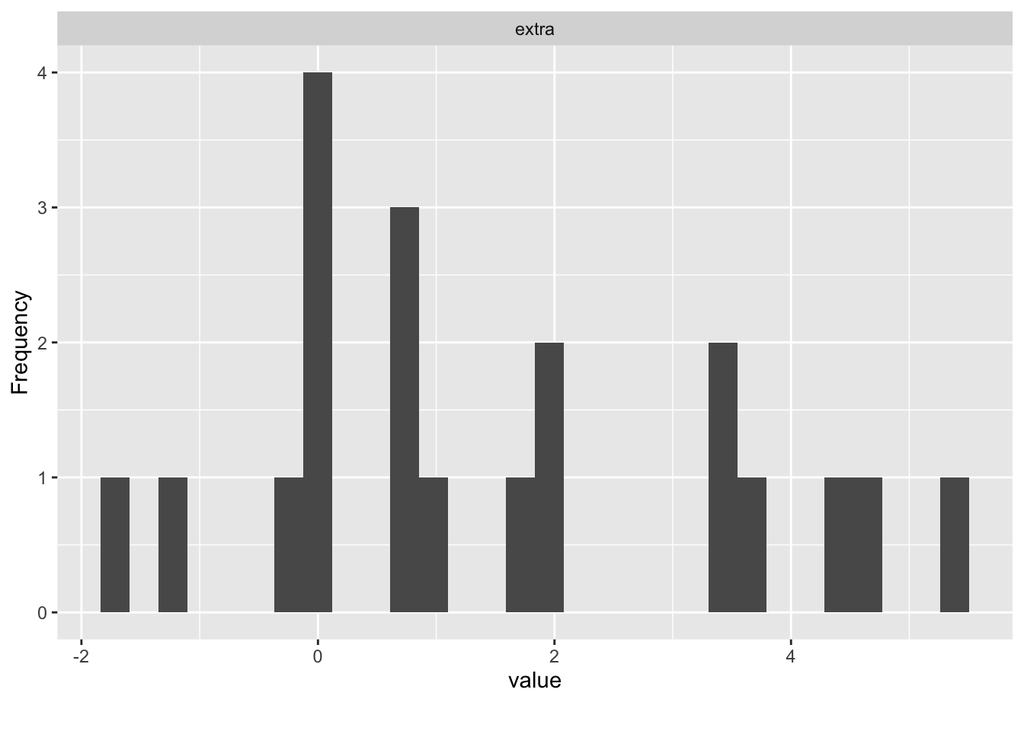

```r
plot_histogram(sleep) # the only continuous variable to examine is "extra" hours of sleep, so there is only one histogram to examine
```

| New dataset to show how model summaries can be output into tables with some of the same commands from the {*kableExtra*} package and kbl() customization commands.

### Model Summary Tables

```r
ttestmodel1 <- list() # the t-test model consists of a list (vector) of information that will be input below
ttestmodel1[["Two-Sample Mean Difference Test"]] <- t.test(extra ~ group, data = sleep) # anything within the [[]] is the model's heading
# within this model is the classic t.test() statistical test, where we specified an independent samples t-test of extra horus of sleep between the two sleep groups
msummary(ttestmodel1,
         statistic = c("conf.int", "p.value"), # statistic = c() can also include 'std.error', 'p.value', 'conf.int' depending on your needs
         stars = TRUE, # "stars" indicates whether or not you want your table footnotes to include asterisks for p-value notations
         conf_level = .95,  # confidence interval was set at 95%
         title = "Fig. 1 Independent-Samples t-Test Model Summary", # title of figure that appears above table
         notes = list("Non-significant difference across sleep groups", "p-value above 0.05")) %>% # the "notes = list()" allows you to input whatever textual information you wish to include at the bottom of the model; I used it as a footnotes area
  row_spec(0, bold = TRUE, background = "lightgray") # This is the same custom command that we used earlier to specify row customizations
```

Fig. 1 Independent-Samples t-Test Model Summary

|  | Two-Sample Mean Difference Test |
| --- | --- |
| extra | 1.580+ |
|  | [-3.365, 0.205] |
|  | (0.079) |
| alternative | two.sided |
| conf.high | 0.205 |
| conf.low | -3.365 |
| estimate | -1.580 |
| estimate1 | 0.750 |
| estimate2 | 2.330 |
| method | Welch Two Sample t-test |
| parameter | 17.776 |

+ p < 0.1, * p < 0.05, ** p < 0.01, *** p < 0.001  
Non-significant difference across sleep groups  
p-value above 0.05

```r
ttestmodel2 <- list()
ttestmodel2 <- t.test(extra ~ group, data = sleep, caption = "Two-Sample Mean Difference Test") # Similarly, implementing the "caption =" portion will give the table a title, but will not be output into the first row as a header. Choose whichever you'd like!
msummary(ttestmodel2, statistic = c("conf.int", "p.value"), conf_level = .95, title = "Fig. 2 Independent-Samples t-Test Model Summary",
         notes = list("Non-significant difference across sleep groups", "p-value above 0.05")) %>%
      add_header_above(c("Statistic" = 1, "Value" = 1)) %>% # Added heading to each column (statistic and value)
  row_spec(0, bold = TRUE, background = "lightgray") # the table heading "Model 1" (row 0) is still bolded and has light gray background
```

Fig. 2 Independent-Samples t-Test Model Summary

| Statistic | Value Model 1 |
| --- | --- |
| extra | 1.580 |
|  | [-3.365, 0.205] |
|  | (0.079) |
| alternative | two.sided |
| conf.high | 0.205 |
| conf.low | -3.365 |
| estimate | -1.580 |
| estimate1 | 0.750 |
| estimate2 | 2.330 |
| method | Welch Two Sample t-test |
| parameter | 17.776 |

Non-significant difference across sleep groups  
p-value above 0.05

```r
regression_model <- list()
regression_model[['Univariate Regression']] <- lm(extra ~ group, data = sleep)
msummary(regression_model,
         statistic = c("std.error", "conf.int", "p.value"),
         stars = TRUE,
         conf_level = .95,
         title = "Fig. 3 Simple Linear Regression Model Summary",
         notes = list("Group is a non-significant predictor of extra sleep", "p-value above 0.05")) %>%
  row_spec(0, bold = TRUE, background = "lightgray") # remember that this is row 0
```

Fig. 3 Simple Linear Regression Model Summary

|  | Univariate Regression |
| --- | --- |
| (Intercept) | 0.750 |
|  | (0.600) |
|  | [-0.511, 2.011] |
|  | (0.228) |
| group2 | 1.580+ |
|  | (0.849) |
|  | [-0.204, 3.364] |
|  | (0.079) |
| Num.Obs. | 20 |
| R2 | 0.161 |
| R2 Adj. | 0.115 |
| AIC | 86.3 |
| BIC | 89.3 |
| Log.Lik. | -40.148 |
| F | 3.463 |

+ p < 0.1, * p < 0.05, ** p < 0.01, *** p < 0.001  
Group is a non-significant predictor of extra sleep  
p-value above 0.05

```r
# if you'd like to edit any other row, use whatever other row number you'd like
# row_spec() can also include align = "center" or "align = "right" if you want to center text
# you can also involve underline = TRUE or strikeout = TRUE if you'd like to use these features
# color = "red" or color = "#123456" will change the color of the text to your desired shade

regression_model2 <- list()
regression_model2[['Univariate Regression']] <- lm(extra ~ group, data = sleep)
msummary(regression_model2,
         statistic = c("std.error", "conf.int", "p.value"),
         stars = TRUE,
         conf_level = .95,
         title = "Fig. 3 Simple Linear Regression Model Summary",
         notes = list("Group is a non-significant predictor of extra sleep", "p-value above 0.05")) %>%
  row_spec(0, bold = TRUE, background = "lightgray") %>%
  row_spec(2, bold = TRUE, background = "yellow") %>% # because we specified row 2, that is the one that is highlit with yellow
  row_spec(3, bold = TRUE, italic = TRUE, color = "red") %>% # because we specified row 3, that is the one italicized and colored red
  column_spec(1, bold = TRUE, background = "green") # because we specified column 1, that is the one with a green background
```

Fig. 3 Simple Linear Regression Model Summary

|  | Univariate Regression |
| --- | --- |
| (Intercept) | 0.750 |
|  | (0.600) |
|  | [-0.511, 2.011] |
|  | (0.228) |
| group2 | 1.580+ |
|  | (0.849) |
|  | [-0.204, 3.364] |
|  | (0.079) |
| Num.Obs. | 20 |
| R2 | 0.161 |
| R2 Adj. | 0.115 |
| AIC | 86.3 |
| BIC | 89.3 |
| Log.Lik. | -40.148 |
| F | 3.463 |

+ p < 0.1, * p < 0.05, ** p < 0.01, *** p < 0.001  
Group is a non-significant predictor of extra sleep  
p-value above 0.05